# Mouse ovary spatial transcriptomics (tutorial)

Curio Seeker 3×3 · one published sample · Seurat

Martin Valny

2026-09-30

## About this tutorial

This notebook is for students and analysts who are new to spatial transcriptomics in Seurat. Using one published mouse ovary section profiled with Curio Seeker 3×3, you will load an AnnData (`.h5ad`) file, run quality control, normalize, find highly variable and spatially variable genes, reduce dimensions, cluster, annotate clusters with canonical ovary markers, map cell types back onto the tissue, measure which cell types sit next to each other, and find marker genes with a Wilcoxon test. Each step explains *why* it is done, and short “Check your understanding” questions test the biology. Plan on 1–2 hours to read it. Knitting it yourself is optional: with ~80,000 beads it can take much longer and needs a machine with plenty of RAM.

## Package Installation

This chunk runs automatically when you knit. It installs only the packages that are missing, so after the first run it takes a second. Seurat and the plotting packages come from CRAN. `rhdf5` (the HDF5 reader) comes from Bioconductor and must match your R version, so it is installed through `BiocManager`.

```r
options(repos = c(CRAN = "https://cloud.r-project.org"))

cran_pkgs <- c("Seurat", "SeuratObject", "ggplot2", "patchwork", "dplyr",
               "Matrix", "scales", "knitr", "rmarkdown", "BiocManager")
missing_cran <- cran_pkgs[!vapply(cran_pkgs, requireNamespace, logical(1), quietly = TRUE)]
if (length(missing_cran) > 0) {
  message("Installing from CRAN: ", paste(missing_cran, collapse = ", "))
  install.packages(missing_cran)
}

if (!requireNamespace("rhdf5", quietly = TRUE)) {
  message("Installing rhdf5 from Bioconductor (release matching R ", getRversion(), ")")
  # update = FALSE / ask = FALSE: don't touch or prompt about other installed packages.
  BiocManager::install("rhdf5", update = FALSE, ask = FALSE)
}

# Fail early with a clear message instead of halfway through the analysis.
still_missing <- c(cran_pkgs, "rhdf5")[!vapply(c(cran_pkgs, "rhdf5"), requireNamespace, logical(1), quietly = TRUE)]
if (length(still_missing) > 0) {
  stop("Could not install: ", paste(still_missing, collapse = ", "),
       ". See the notes below this chunk.", call. = FALSE)
}
```

If `rhdf5` fails to install:

- **Check your R version** with `R.version.string`. Bioconductor builds each release for one R version, so a very old or brand-new R can have no matching binary. Updating R to the current release usually fixes this.
- **Check the Bioconductor setup** with `BiocManager::valid()`. It reports version mismatches and how to fix them.
- **macOS:** if R tries to compile from source, install the command-line tools once with `xcode-select --install` in a terminal, then retry.

```r
library(Seurat)
library(ggplot2)
library(patchwork)
library(dplyr)
library(Matrix)
library(rhdf5)   # Bioconductor HDF5 reader (installed above via BiocManager)

set.seed(42)
```

## Background

This tutorial walks through an end-to-end analysis of a single ovary sample from:

> Mantri M, Zhang HH, Spanos E, Ren YA, De Vlaminck I. **“A spatiotemporal molecular atlas of the ovulating mouse ovary.”** *Proc Natl Acad Sci USA* 121(5):e2317418121 (2024). https://doi.org/10.1073/pnas.2317418121

> Data: NCBI GEO GSE240271. This tutorial uses sample GSM7689281 (1 h after hCG) by default.

The data were generated with the **Curio Seeker 3×3** platform: a bead-based spatial transcriptomics assay capturing mRNA from a 3 mm × 3 mm tissue section onto ~80,000 spatially-indexed beads at 10 µm resolution (~1–2 cells per bead).

**Expected major cell types:**

| Cell type | Key markers |
| --- | --- |
| Oocyte | *Gdf9*, *Zp3*, *Nobox*, *Figla* |
| Granulosa — mural | *Foxl2*, *Cyp19a1*, *Amh*, *Inha* |
| Granulosa — cumulus | *Ptx3*, *Has2*, *Ptger2* |
| Theca | *Cyp17a1*, *Star*, *Lhcgr* |
| Stroma / fibroblast | *Dcn*, *Col1a1*, *Pdgfra* |
| Smooth muscle | *Acta2*, *Tagln* |
| Endothelial | *Pecam1*, *Cdh5* |

**Platform context — Curio Seeker 3×3 vs. alternatives:**

| Platform | Resolution | Area / spots | Genes | Notes |
| --- | --- | --- | --- | --- |
| **Curio Seeker 3×3** | **10 µm** | 3×3 mm, ~80 k beads | Whole transcriptome | ~1–2 cells/bead; random bead placement; passive capture |
| 10x Visium | 55 µm | 6.5×6.5 mm, ~5 k spots | Whole transcriptome | ~10–15 cells/spot; grid layout; H&E image overlay |
| 10x Xenium / CosMx | Sub-cellular | Flexible | 200–5,000 (targeted) | FISH-based; no library prep; very high cost |
| Slide-seq v2 | 10 µm | ~3 mm diameter | Whole transcriptome | Similar resolution to Curio; more complex library prep |

## Data Loading

Download the sample with `python scripts/fetch_data.py` (see the README). It writes `data/sample.h5ad`. The matrix is public on GEO, so do not commit it to git: `data/*.h5ad` is already in `.gitignore`.

```r
# ── Path to the .h5ad written by scripts/fetch_data.py ───────────────────────
H5_PATH <- "data/sample.h5ad"
```

```r
# The .h5ad (AnnData) format is HDF5-based. We inspect it with rhdf5::h5ls(),
# which lists all groups and datasets without opening a persistent file handle.

cat("Top-level keys in .h5ad:\n")
```

```
## Top-level keys in .h5ad:
```

```r
top_keys <- h5ls(H5_PATH, recursive = FALSE)
print(top_keys$name)
```

```
## [1] "X"      "layers" "obs"    "obsm"   "obsp"   "uns"    "var"    "varm"
## [9] "varp"
```

```r
# ── Count matrix ──────────────────────────────────────────────────────────────
# AnnData stores the matrix in /X. It can be dense (2D dataset) or sparse
# (a group with /X/data, /X/indices, /X/indptr following CSR format).

# rhdf5 returns strings as 1-D arrays; Seurat v5 needs plain character vectors,
# so convert them (and make sure names are unique).
obs_names <- make.unique(as.character(h5read(H5_PATH, "/obs/_index")))  # bead barcodes (rows in AnnData)
var_names <- make.unique(as.character(h5read(H5_PATH, "/var/_index")))  # gene names    (cols in AnnData)

# Determine whether /X is sparse (group with data/indices/indptr) or dense
x_subkeys <- tryCatch(
  { xl <- h5ls(H5_PATH); xl$name[xl$group == "/X"] },
  error = function(e) character(0)
)

if (all(c("data", "indices", "indptr") %in% x_subkeys)) {
  # Sparse CSR matrix
  cat("Sparse CSR matrix detected\n")
  sp_data    <- h5read(H5_PATH, "/X/data")
  sp_indices <- h5read(H5_PATH, "/X/indices")
  sp_indptr  <- h5read(H5_PATH, "/X/indptr")
  n_obs <- length(obs_names)
  n_var <- length(var_names)
  # AnnData CSR: rows = obs (beads), cols = var (genes)
  # Seurat expects genes × beads, so we build transposed
  counts_sparse <- sparseMatrix(
    i    = sp_indices + 1L,   # 0-indexed → 1-indexed
    p    = sp_indptr,
    x    = as.numeric(sp_data),
    dims = c(n_var, n_obs),
    dimnames = list(var_names, obs_names)
  )
} else {
  # Dense matrix — AnnData shape is (n_obs × n_var)
  cat("Dense matrix detected\n")
  mat_raw <- h5read(H5_PATH, "/X")
  counts_sparse <- Matrix(t(mat_raw), sparse = TRUE)
  rownames(counts_sparse) <- var_names
  colnames(counts_sparse) <- obs_names
}
```

```
## Sparse CSR matrix detected
```

```r
cat(sprintf("Matrix: %d genes × %d beads\n", nrow(counts_sparse), ncol(counts_sparse)))
```

```
## Matrix: 31053 genes × 77202 beads
```

```r
# ── Spatial coordinates ───────────────────────────────────────────────────────
# Curio Seeker stores bead XY positions in obsm/spatial (shape: n_obs × 2).

spatial_coords <- tryCatch({
  raw <- h5read(H5_PATH, "/obsm/spatial")
  # rhdf5 reads HDF5 arrays in column-major order; result may be (2 × n_obs)
  if (nrow(raw) == 2) {
    df <- as.data.frame(t(raw))
  } else {
    df <- as.data.frame(raw)
  }
  colnames(df) <- c("x", "y")
  rownames(df) <- obs_names
  cat(sprintf("Spatial coords: %d beads\n", nrow(df)))
  df
}, error = function(e) {
  cat("No spatial coordinates found — proceeding without spatial plots.\n")
  NULL
})
```

```
## Spatial coords: 77202 beads
```

```r
# ── Seurat object ─────────────────────────────────────────────────────────────
obj <- CreateSeuratObject(
  counts      = counts_sparse,
  project     = "OvarySeeker3x3",
  min.cells   = 3,    # keep genes detected in ≥3 beads
  min.features = 10   # keep beads expressing ≥10 genes (removes empty beads)
)

# Store spatial coordinates in metadata
if (!is.null(spatial_coords)) {
  shared <- intersect(colnames(obj), rownames(spatial_coords))
  obj$x_coord <- spatial_coords[shared, "x"]
  obj$y_coord <- spatial_coords[shared, "y"]
}

print(obj)
```

```
## An object of class Seurat
## 16768 features across 39827 samples within 1 assay
## Active assay: RNA (16768 features, 0 variable features)
##  1 layer present: counts
```

## Step 1: Quality Control

QC identifies and removes low-quality beads. For Curio Seeker 3×3 (10 µm beads, 1–2 cells each), three metrics matter:

- **`nFeature_RNA`** — genes detected per bead. Too few → empty bead; too many → bead doublet.
- **`nCount_RNA`** — total UMIs per bead. Reflects capture efficiency.
- **`percent.mt`** — mitochondrial gene fraction. High % indicates stressed/dead cells whose cytoplasmic mRNA has leaked, leaving mitochondrially-encoded transcripts over-represented.

Seeker beads typically yield lower gene counts than droplet-based platforms (10x Chromium) because each bead covers ~10 µm vs. a single isolated cell. Thresholds are set accordingly.

```r
obj[["percent.mt"]] <- PercentageFeatureSet(obj, pattern = "^mt-")

summary(obj@meta.data[, c("nFeature_RNA", "nCount_RNA", "percent.mt")])
```

```
##   nFeature_RNA      nCount_RNA       percent.mt
##  Min.   :  10.0   Min.   :  10.0   Min.   : 0.000
##  1st Qu.: 124.0   1st Qu.: 141.0   1st Qu.: 2.679
##  Median : 280.0   Median : 350.0   Median : 3.706
##  Mean   : 380.5   Mean   : 575.6   Mean   : 4.070
##  3rd Qu.: 539.0   3rd Qu.: 772.0   3rd Qu.: 5.089
##  Max.   :3384.0   Max.   :9798.0   Max.   :30.000
```

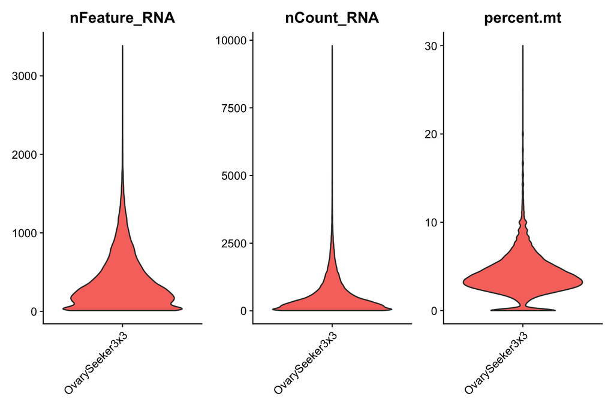

QC metrics across all beads before filtering.

```r
VlnPlot(
  obj,
  features = c("nFeature_RNA", "nCount_RNA", "percent.mt"),
  ncol = 3, pt.size = 0
) & theme(axis.title.x = element_blank())
```

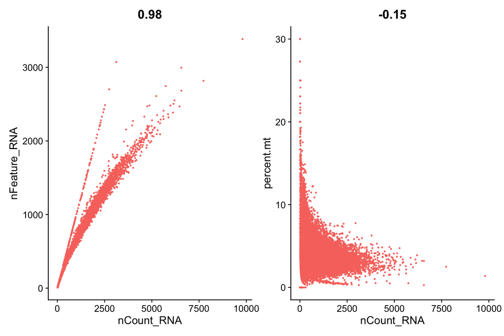

Scatter plots to identify outlier beads and set thresholds.

```r
p1 <- FeatureScatter(obj, "nCount_RNA", "nFeature_RNA", pt.size = 0.3) + NoLegend()
p2 <- FeatureScatter(obj, "nCount_RNA", "percent.mt",   pt.size = 0.3) + NoLegend()
p1 + p2
```

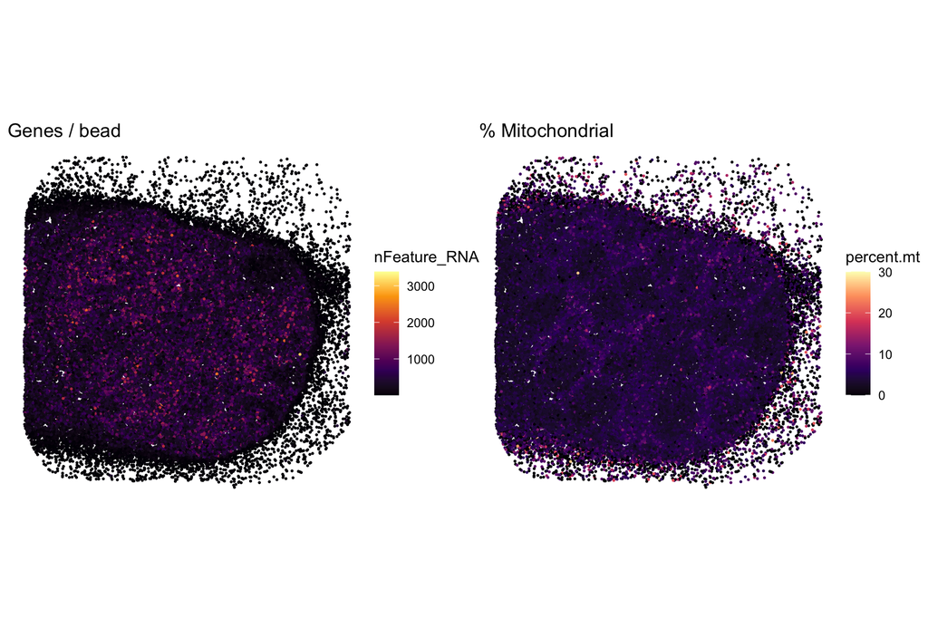

Spatial QC: genes per bead and mito fraction mapped onto the tissue.

```r
if (!is.null(obj$x_coord)) {
  meta <- obj@meta.data
  g1 <- ggplot(meta, aes(x_coord, y_coord, colour = nFeature_RNA)) +
    geom_point(size = 0.3) + scale_colour_viridis_c(option = "B") +
    coord_fixed() + theme_void() + labs(title = "Genes / bead")
  g2 <- ggplot(meta, aes(x_coord, y_coord, colour = percent.mt)) +
    geom_point(size = 0.3) + scale_colour_viridis_c(option = "A") +
    coord_fixed() + theme_void() + labs(title = "% Mitochondrial")
  g1 + g2
}
```

```r
n_before <- ncol(obj)

obj <- subset(
  obj,
  subset = nFeature_RNA  > 200  &
           nFeature_RNA  < 6000 &
           nCount_RNA    > 500  &
           percent.mt    < 20
)

cat(sprintf("Beads: %d → %d  (%.1f%% removed)\n",
            n_before, ncol(obj), 100 * (1 - ncol(obj)/n_before)))
```

```
## Beads: 39827 → 15135  (62.0% removed)
```

> **Check your understanding — Quality Control**

> A subset of beads shows very high mitochondrial gene fraction (>30%) alongside very low total UMI counts. What is the most likely biological explanation?
> 1. These beads captured oocytes, which naturally express many mitochondrial genes due to their high metabolic activity
> 2. These beads captured damaged or dying cells whose cytoplasmic mRNA has leaked out, leaving primarily mitochondrially-encoded transcripts
> 3. These beads are in the corpus luteum, which is rich in mitochondria for steroidogenesis
> 4. These beads represent theca cells undergoing active androgen biosynthesis

> **Answer: B** — High mito% combined with low total UMI is the molecular signature of a broken or apoptotic cell. The cell membrane is compromised, cytoplasmic mRNA degrades or leaks, but membrane-bound mitochondria retain their transcripts. This pattern reflects cell damage, not any particular cell type identity.

## Step 2: Normalization

Raw UMI counts vary between beads due to capture efficiency, sequencing depth, and cell size — not genuine biology. Normalization removes these technical differences so gene expression values are comparable across beads.

**Method: Log-normalization** Each bead’s counts are scaled to a common total (10,000 UMI), then log(1+x)-transformed. This compresses the dynamic range and makes the distribution more approximately normal — an assumption of downstream linear methods (PCA, DE tests).

```r
obj <- NormalizeData(
  obj,
  normalization.method = "LogNormalize",
  scale.factor         = 10000
)
# Raw counts preserved in obj[["RNA"]]$counts
# Normalized values in obj[["RNA"]]$data
cat("Normalization complete.\n")
```

```
## Normalization complete.
```

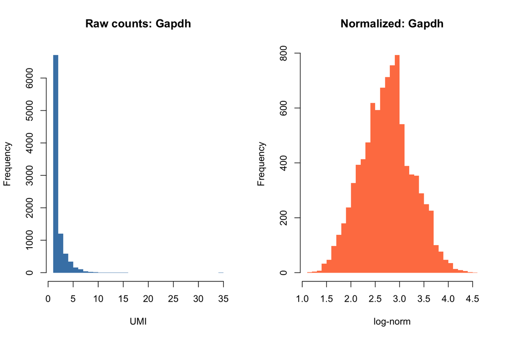

A housekeeping gene (Gapdh) before and after normalization. Normalization reduces correlation between total counts and individual gene expression.

```r
gene <- if ("Gapdh" %in% rownames(obj)) "Gapdh" else rownames(obj)[1]

raw_vals  <- obj[["RNA"]]$counts[gene, ]
norm_vals <- obj[["RNA"]]$data[gene, ]

par(mfrow = c(1, 2))
hist(raw_vals [raw_vals  > 0], breaks = 40, col = "steelblue", border = NA,
     main = paste("Raw counts:", gene), xlab = "UMI")
hist(norm_vals[norm_vals > 0], breaks = 40, col = "coral",     border = NA,
     main = paste("Normalized:", gene), xlab = "log-norm")
```

```r
par(mfrow = c(1, 1))
```

> **Check your understanding — Normalization**

> We normalize UMI counts before comparing gene expression across beads. Which statement best captures the PRIMARY biological motivation for this step in ovarian cell typing?
> 1. Normalization removes batch effects introduced during tissue dissection
> 2. Normalization corrects for sequencing depth and mRNA capture differences so that observed gene expression differences reflect true biology, not technical variation
> 3. Normalization sets housekeeping genes to zero, making cell-type markers more prominent
> 4. Normalization converts counts to TPM, which Seurat requires for clustering

> **Answer: B** — A granulosa bead sequenced to 5,000 UMIs would appear to “express more” of every gene than one sequenced to 1,000 UMIs. Without normalization this technical variation would dominate clustering, grouping beads by sequencing depth rather than cell identity.

## Step 3: Feature Selection

The mouse genome has ~20,000 protein-coding genes, but most are either unexpressed or constitutively expressed at similar levels across all cell types. Including these uninformative genes adds noise without helping distinguish oocytes from granulosa cells.

**Method: Variance-stabilizing transformation (VST)** VST models the expected relationship between a gene’s mean expression and its variance. Genes whose variance exceeds what is expected for their mean are “highly variable” — these capture biological differences between cell types. We retain the top 2,000 HVGs for all downstream steps.

```r
obj <- FindVariableFeatures(
  obj,
  selection.method = "vst",
  nfeatures        = 2000
)

cat(sprintf("Top 10 HVGs: %s\n",
            paste(head(VariableFeatures(obj), 10), collapse = ", ")))
```

```
## Top 10 HVGs: Hbb-bs, Hba-a2, Gdf9, Hba-a1, Nlrp14, Khdc1b, Hbb-bt, H1foo, Padi6, Gm42418
```

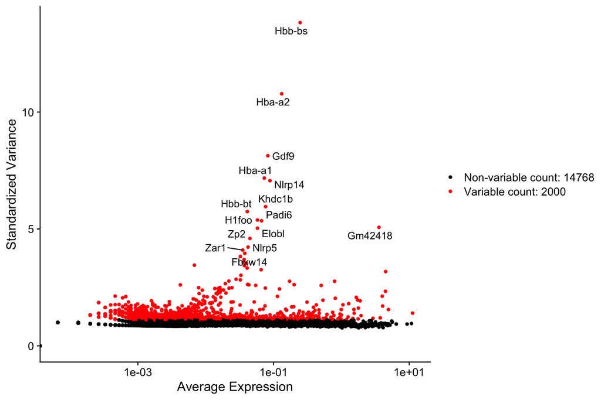

Mean–variance plot. Red points are the 2,000 selected HVGs; top 15 are labeled. Genes above the fitted curve vary more than expected for their expression level.

```r
top15 <- head(VariableFeatures(obj), 15)
p <- VariableFeaturePlot(obj)
LabelPoints(plot = p, points = top15, repel = TRUE, xnudge = 0, ynudge = 0)
```

> **Check your understanding — Feature Selection**

> After selecting ~2,000 highly variable genes from ~20,000, we use only HVGs for all downstream clustering and dimensionality reduction. Why does this improve cell type separation in the ovary dataset?
> 1. Using fewer genes speeds up computation and the result is identical to using all genes
> 2. Most genes are constitutively expressed at similar levels across granulosa, theca, oocyte, and stroma cells; retaining only genes that vary across cell types removes noise and sharpens the transcriptomic signatures that define each lineage
> 3. VST removes mitochondrial genes that would otherwise confound clustering
> 4. Seurat’s clustering algorithm requires exactly 2,000 genes as input

> **Answer: B** — Constitutive housekeeping genes (e.g., ribosomal proteins, metabolic enzymes) are expressed by every cell type. They add variance without biological discriminatory power. HVGs — the genes that differ between an oocyte and a granulosa cell — carry the signal needed to resolve distinct clusters.

## Step 3b: Spatially Variable Genes (SVGs)

HVGs capture *transcriptional* variation across beads regardless of where they sit in the tissue. **Spatially variable genes (SVGs)** go further: they identify genes whose expression is spatially autocorrelated — forming coherent expression domains in the tissue rather than appearing as scattered high-variance noise.

This is the key analytical advantage of spatial over conventional scRNA-seq: spatial structure is informative biology (follicle boundaries, vascular channels, immune niches), not just noise. Moran’s I quantifies whether nearby beads tend to express a gene at similar levels (positive autocorrelation = spatially structured) versus randomly.

```r
# ── Spatially Variable Gene analysis ──────────────────────────────────────────
# Requires spatial coordinates. Uses a Gaussian kernel weight matrix to score
# each HVG for spatial autocorrelation (Moran's I statistic).
# Only runs if spatial coordinates were loaded successfully.

if (!is.null(obj$x_coord)) {
  # Scale and PCA first (needed for SVG selection in Seurat v5 workflow)
  obj_svg <- ScaleData(obj, features = VariableFeatures(obj), verbose = FALSE)
  obj_svg <- RunPCA(obj_svg, features = VariableFeatures(obj_svg),
                   npcs = 30, verbose = FALSE)

  # Build a simple spatial weight matrix (Gaussian kernel, sigma = 50 µm)
  # and compute Moran's I for each HVG
  coords_mat <- as.matrix(obj@meta.data[, c("x_coord", "y_coord")])

  # Euclidean distance matrix (can be slow for >20k beads; sample if needed)
  n_beads <- nrow(coords_mat)
  if (n_beads > 5000) {
    set.seed(42)
    idx <- sample(n_beads, 5000)
    coords_sub <- coords_mat[idx, ]
  } else {
    idx <- seq_len(n_beads)
    coords_sub <- coords_mat
  }

  dist_mat <- as.matrix(dist(coords_sub))
  sigma     <- 50   # spatial bandwidth in coordinate units (~µm)
  W         <- exp(-dist_mat^2 / (2 * sigma^2))
  diag(W)   <- 0
  W         <- W / rowSums(W)   # row-normalise

  # Compute Moran's I for each HVG on the subsampled beads
  hvgs <- VariableFeatures(obj)
  expr_sub <- as.matrix(
    GetAssayData(obj, layer = "data")[hvgs, colnames(obj)[idx]]
  )

  moran_i <- apply(expr_sub, 1, function(x) {
    xc <- x - mean(x)
    n  <- length(x)
    denom <- sum(xc^2)
    if (denom == 0) return(NA_real_)
    (n / sum(W)) * (as.numeric(xc %*% W %*% xc) / denom)
  })

  svg_df <- data.frame(
    gene    = hvgs,
    moran_i = moran_i
  ) |>
    filter(!is.na(moran_i)) |>
    arrange(desc(moran_i))

  cat("Top 10 spatially variable genes (by Moran's I):\n")
  print(head(svg_df, 10))
}
```

```
## Top 10 spatially variable genes (by Moran's I):
##                        gene   moran_i
## Inhba                 Inhba 0.4284636
## Sfrp4                 Sfrp4 0.3826733
## Cyp11a1             Cyp11a1 0.3694181
## Inhbb                 Inhbb 0.3468107
## Khdc1b               Khdc1b 0.3308280
## E330034G19Rik E330034G19Rik 0.3062180
## Nlrp14               Nlrp14 0.3060541
## Hsd3b1               Hsd3b1 0.2932948
## H1foo                 H1foo 0.2875556
## C86187               C86187 0.2868159
```

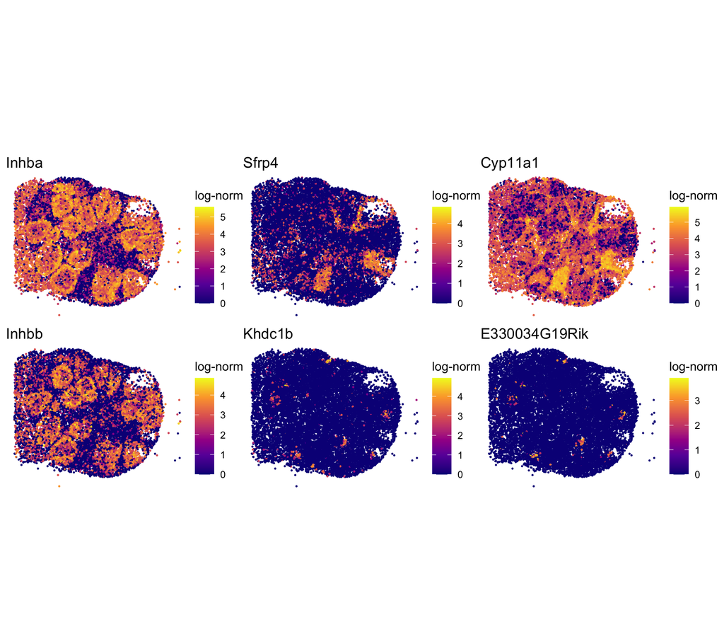

Spatial expression of the top 6 SVGs. Genes with high Moran’s I form coherent expression domains corresponding to tissue compartments — follicle layers, stroma, vasculature — rather than random scatter.

```r
if (!is.null(obj$x_coord) && exists("svg_df")) {
  top_svgs <- head(svg_df$gene, 6)
  top_svgs <- intersect(top_svgs, rownames(obj))

  meta <- obj@meta.data
  plots <- lapply(top_svgs, function(g) {
    expr <- GetAssayData(obj, layer = "data")[g, ]
    meta$expr <- expr
    ggplot(meta, aes(x_coord, y_coord, colour = expr)) +
      geom_point(size = 0.25) +
      scale_colour_viridis_c(option = "C") +
      coord_fixed() + theme_void() +
      labs(title = g, colour = "log-norm")
  })

  patchwork::wrap_plots(plots, ncol = 3)
}
```

> **Check your understanding — Spatially Variable Genes**

> HVG analysis and SVG analysis both rank genes by how much they vary across the dataset. What is the fundamental difference between a gene that is merely “highly variable” and one that is “spatially variable” in this ovary section?
> 1. SVGs have higher average expression than HVGs
> 2. A spatially variable gene shows expression that is autocorrelated with physical location — nearby beads tend to share similar expression values — forming biologically meaningful tissue domains, whereas a plain HVG can vary randomly across the slide without spatial structure
> 3. SVGs are restricted to the top 200 most expressed genes per cluster
> 4. HVGs and SVGs are identical; the terms are interchangeable in spatial analysis

> **Answer: B** — Spatial autocorrelation (Moran’s I) measures whether a gene’s expression in one bead predicts expression in its physical neighbors. High Moran’s I genes delineate real tissue compartments: a follicle boundary gene will be high in all beads inside the follicle and low outside, creating a spatially coherent patch. A plain HVG might vary stochastically across beads with no geographic pattern — informative for cell typing but not for tissue architecture.

## Step 4: Dimensionality Reduction

Even 2,000 genes form a high-dimensional space where distances are hard to interpret. Dimensionality reduction compresses this into a low-dimensional summary that preserves the most important structure.

**Two-stage:**

1. **PCA** — linear projection capturing the major axes of transcriptional variation. We use the top PCs (chosen from an elbow plot) as input for graph construction.
2. **UMAP** — non-linear method that takes the PCA neighbourhood graph as input and produces a 2D visualization preserving local structure.

```r
# Scale all HVGs to zero mean / unit variance before PCA
obj <- ScaleData(obj, features = VariableFeatures(obj))

obj <- RunPCA(obj, features = VariableFeatures(obj), npcs = 50, verbose = FALSE)

# Genes most strongly loading each PC
print(obj[["pca"]], dims = 1:3, nfeatures = 5)
```

```
## PC_ 1
## Positive:  Hsd3b1, Cyp11a1, Malat1, Sparc, Fdx1
## Negative:  H1foo, Khdc1b, Fbxw14, Trim61, E330034G19Rik
## PC_ 2
## Positive:  Inhba, Serpine2, Inhbb, Inha, Nap1l5
## Negative:  Sparc, Cyp11a1, Igfbp7, Tmsb4x, Col1a2
## PC_ 3
## Positive:  Sfrp4, Gm2a, Sdc1, Hsd17b7, Scarb1
## Negative:  Col1a2, Igfbp7, Acta2, Myl9, Col3a1
```

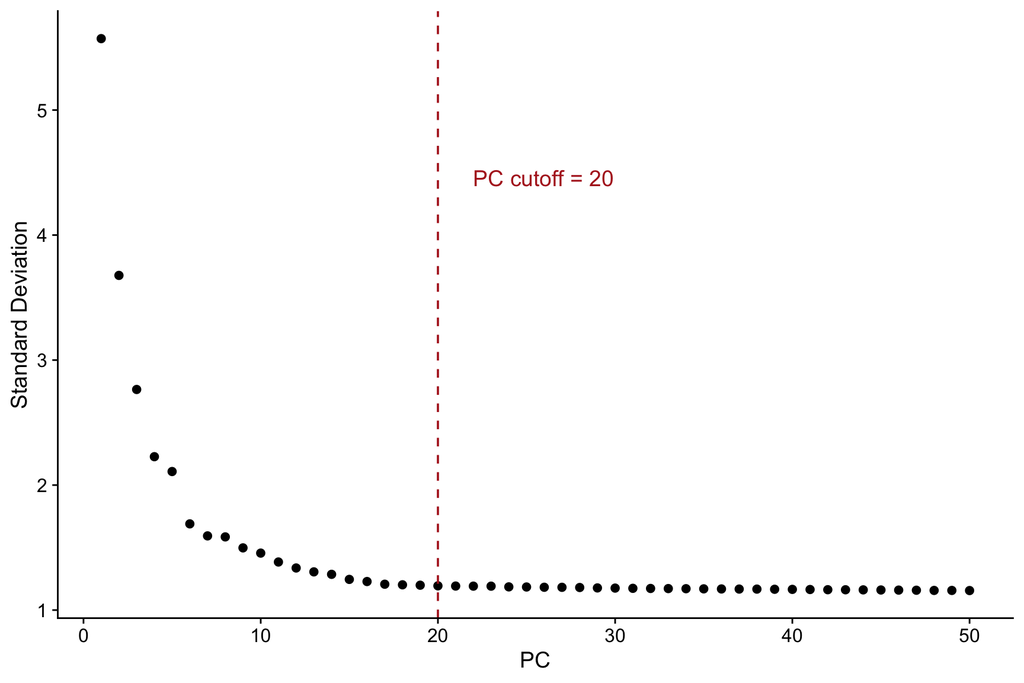

Elbow plot: standard deviation explained by each PC. The dashed line marks the chosen cutoff where the curve begins to flatten.

```r
ElbowPlot(obj, ndims = 50) +
  geom_vline(xintercept = 20, linetype = "dashed", colour = "firebrick") +
  annotate("text", x = 22, y = max(obj[["pca"]]@stdev) * 0.8,
           label = "PC cutoff = 20", colour = "firebrick", hjust = 0)
```

```r
N_PCS <- 20   # adjust based on elbow plot

obj <- FindNeighbors(obj, dims = 1:N_PCS, verbose = FALSE)
obj <- RunUMAP(obj, dims = 1:N_PCS, verbose = FALSE)
```

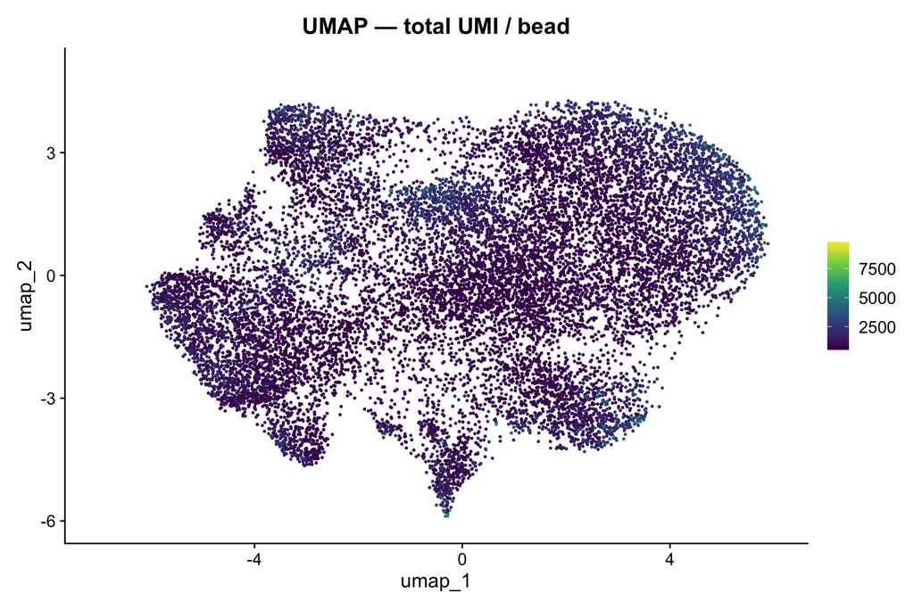

UMAP coloured by total UMI. Well-separated lobes indicate distinct transcriptomic identities; colour uniformity within lobes confirms the embedding is not driven by sequencing depth.

```r
FeaturePlot(obj, features = "nCount_RNA", pt.size = 0.3) +
  scale_colour_viridis_c() + ggtitle("UMAP — total UMI / bead")
```

> **Check your understanding — Dimensionality Reduction**

> After embedding the ovary transcriptome in UMAP space, one cluster forms a clearly isolated island — consistently separate from all other clusters regardless of resolution. Which cell type most likely occupies this isolated position, and why?
> 1. Theca cells — they surround the follicle and have a unique steroidogenic program
> 2. Stromal fibroblasts — they are the most abundant cell type
> 3. Oocytes — their transcriptome is dominated by a germline maternal mRNA program (*Gdf9*, *Zp3*, *Figla*) with essentially no overlap with somatic cell lineages
> 4. Endothelial cells — they express a vascular program distinct from parenchymal cells

> **Answer: C** — The oocyte is the only germline-derived cell in the ovary. Its transcriptome is built around maternal mRNA storage and oocyte-specific developmental factors (*Gdf9*, *Zp3*, *Nobox*, *Figla*) that are absent from all somatic lineages. This makes oocytes the most transcriptomically isolated population in any ovarian dataset.

## Step 5: Clustering

Clustering groups beads with similar gene expression into discrete clusters that correspond to cell types (or cell states). We use a graph-based approach that scales to large datasets and does not require pre-specifying the number of clusters.

**Method: SNN graph + Louvain community detection** A shared-nearest-neighbor (SNN) graph is constructed in PCA space; beads sharing many neighbors receive higher edge weights. The Louvain algorithm maximizes graph modularity to find natural communities. The `resolution` parameter controls granularity — we test several values and select based on biological coherence after annotation.

```r
obj <- FindClusters(obj, resolution = c(0.3, 0.5, 0.8), verbose = FALSE)

# Use resolution 0.5 as working resolution
Idents(obj) <- "RNA_snn_res.0.5"
cat(sprintf("Clusters at res 0.5: %d\n", nlevels(Idents(obj))))
```

```
## Clusters at res 0.5: 9
```

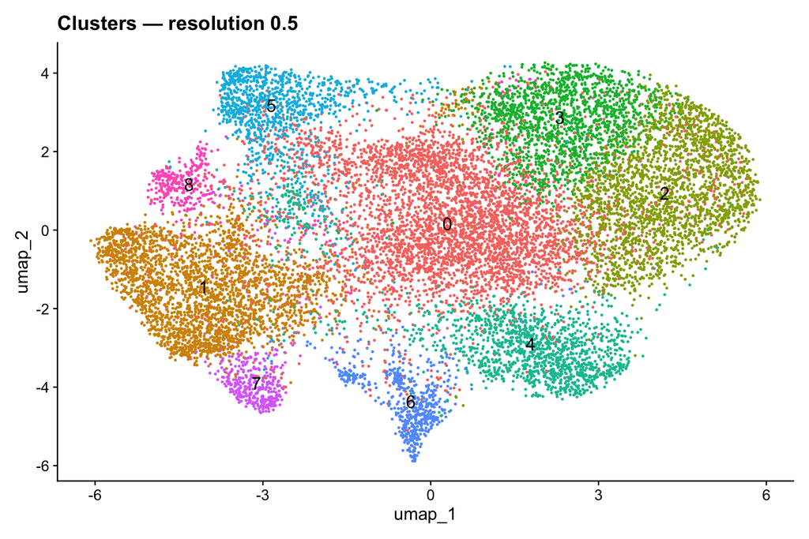

UMAP coloured by cluster (resolution = 0.5). Each numbered cluster will be annotated in Step 6.

```r
DimPlot(obj, reduction = "umap", label = TRUE, label.size = 5, pt.size = 0.3) +
  ggtitle("Clusters — resolution 0.5") + NoLegend()
```

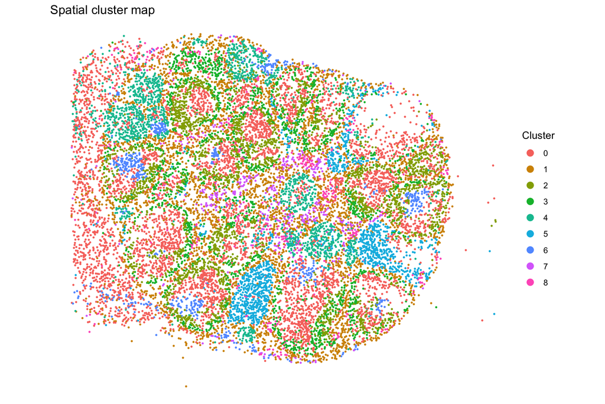

Clusters mapped onto the tissue section. Spatially coherent clusters validate that transcriptomic communities correspond to real tissue compartments.

```r
if (!is.null(obj$x_coord)) {
  meta       <- obj@meta.data
  meta$cluster <- Idents(obj)
  ggplot(meta, aes(x_coord, y_coord, colour = cluster)) +
    geom_point(size = 0.4) + coord_fixed() + theme_void() +
    labs(title = "Spatial cluster map", colour = "Cluster") +
    guides(colour = guide_legend(override.aes = list(size = 3)))
}
```

> **Check your understanding — Clustering**

> After clustering the ovary data, one major tissue compartment consistently resolves into more sub-clusters than the other — even at lower resolution settings. Which compartment shows this greater heterogeneity, and what best explains it?
> 1. Stromal compartment — fibroblasts, smooth muscle, and endothelial cells are indistinguishable from one another
> 2. Follicular compartment (granulosa + cumulus + oocyte) — granulosa cells exist in multiple functional states tied to follicle maturation (preantral, antral, periovulatory, luteinizing), creating several distinct transcriptomic subtypes within a single lineage
> 3. Follicular compartment — the large size of oocytes inflates the cluster count
> 4. Both compartments always produce the same number of clusters

> **Answer: B** — Mural granulosa cells progress through a continuous developmental trajectory as follicles mature. Mantri *et al.* describe several granulosa subtypes (preantral, antral, atretic, periovulatory/lytic). This developmental heterogeneity creates multiple transcriptomically distinct sub-populations within a single somatic lineage, driving higher cluster counts in the follicular compartment.

## Step 6: Cell Typing

We annotate clusters by examining expression of canonical marker genes from the literature and Mantri *et al.* (2024). This translates computational cluster IDs into biologically interpretable cell type labels.

**Strategy:** Score each bead for a panel of marker genes using `AddModuleScore()`, visualize with `DotPlot()` and `FeaturePlot()`, then assign cell type labels manually.

```r
# Canonical markers per cell type (from Mantri et al. 2024 + established literature)
cell_markers <- list(
  Oocyte          = c("Gdf9", "Zp3", "Nobox", "Figla", "Ooep"),
  Granulosa_mural = c("Foxl2", "Cyp19a1", "Amh", "Inha", "Fshr"),
  Cumulus         = c("Ptx3", "Has2", "Ptger2", "Tnfaip6"),
  Theca           = c("Cyp17a1", "Star", "Lhcgr", "Insl3"),
  Stroma          = c("Dcn", "Col1a1", "Pdgfra", "Vim"),
  SmoothMuscle    = c("Acta2", "Tagln", "Myl9"),
  Endothelial     = c("Pecam1", "Cdh5", "Vegfa")
)

# Filter to genes present in our dataset
available_markers <- lapply(cell_markers, function(g) intersect(g, rownames(obj)))
cat("Markers available per cell type:\n")
```

```
## Markers available per cell type:
```

```r
print(sapply(available_markers, length))
```

```
##          Oocyte Granulosa_mural         Cumulus           Theca          Stroma
##               5               5               3               4               4
##    SmoothMuscle     Endothelial
##               3               3
```

```r
# Score each bead for each cell type gene module
obj <- AddModuleScore(
  obj,
  features = available_markers,
  name     = "Score",
  seed     = 42
)
# Rename score columns for readability
score_idx  <- seq_along(cell_markers)
old_names  <- paste0("Score", score_idx)
new_names  <- paste0("Score_", names(cell_markers))
idx        <- match(old_names, colnames(obj@meta.data))
colnames(obj@meta.data)[idx] <- new_names
```

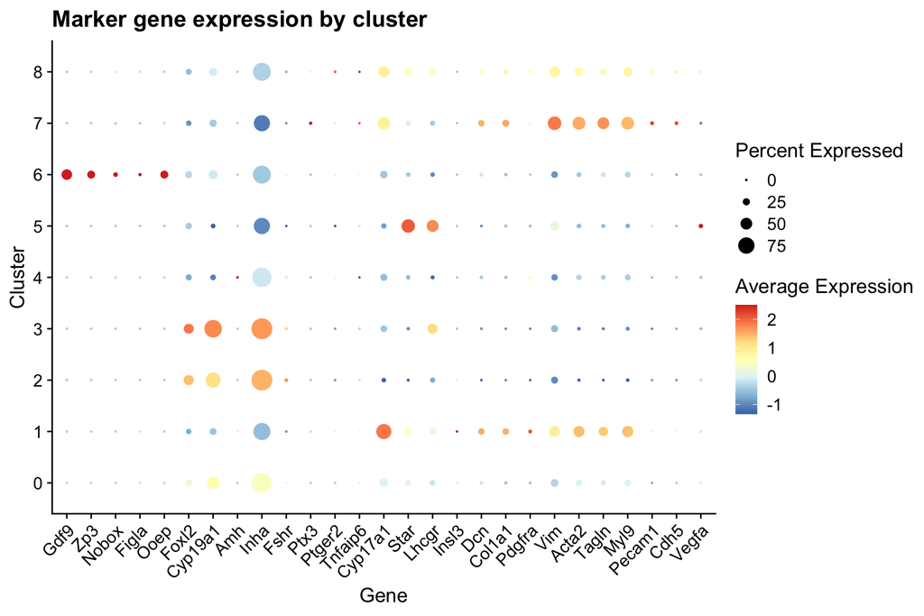

DotPlot of canonical markers by cluster. Dot size = fraction of beads expressing the gene; colour = scaled average expression. Use this to assign cell type labels to clusters.

```r
all_genes <- unique(unlist(available_markers))

DotPlot(obj, features = all_genes, dot.scale = 6) +
  RotatedAxis() +
  scale_colour_distiller(palette = "RdYlBu", direction = -1) +
  labs(title = "Marker gene expression by cluster", x = "Gene", y = "Cluster")
```

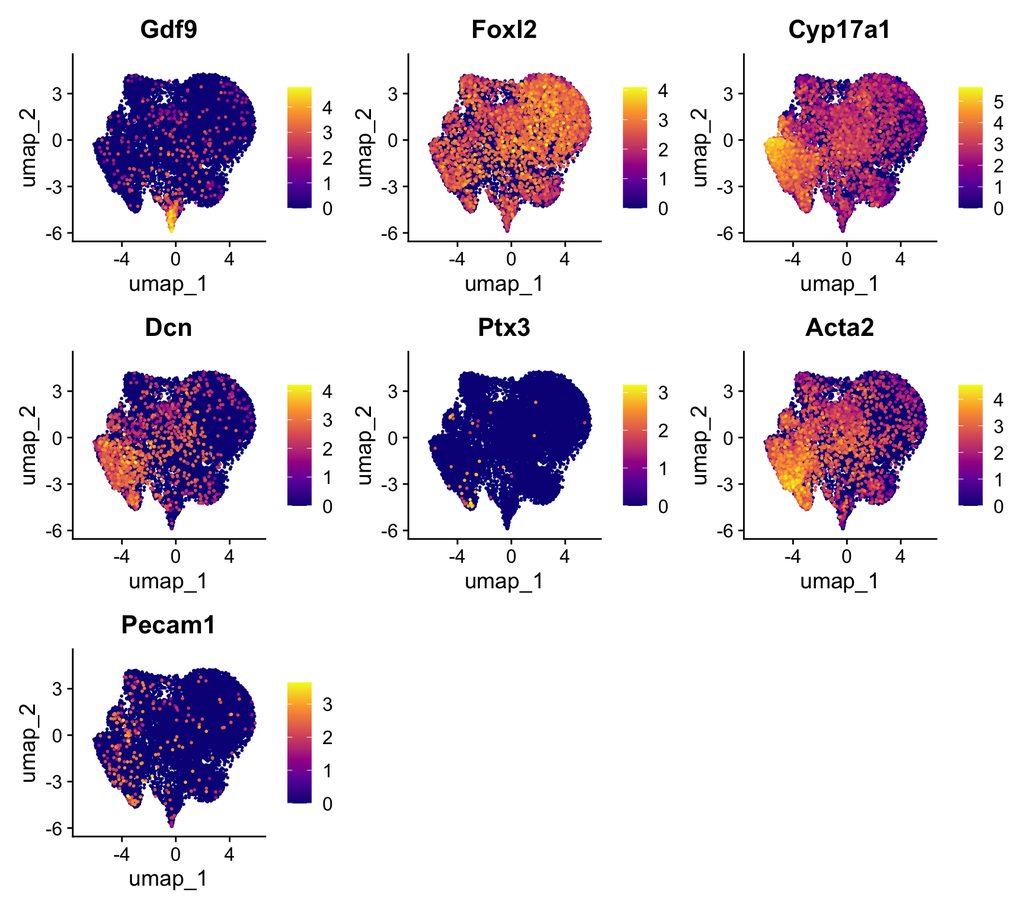

```r
key_genes <- c("Gdf9", "Foxl2", "Cyp17a1", "Dcn", "Ptx3", "Acta2", "Pecam1")
key_genes <- intersect(key_genes, rownames(obj))

FeaturePlot(obj, features = key_genes, ncol = 3, pt.size = 0.2, order = TRUE) &
  scale_colour_viridis_c(option = "C")
```